# scATAC annotation level 1 with KNN

Paula Soler-Vila & Ramon Massoni-Badosa

1 June 2021

# 1 Introduction

Here, we will apply a k-nearest neighbor (KNN) algorithm to classify the scATAC cells to a given cell type category with the help of our training set, the Multiome experiment. Remember, that KNN works on a basic assumption that data points of similar categories are closer to each other.

# 2 Pre-processing

## 2.1 Load packages

```r
library(Seurat)
library(Signac)
library(flexclust)
library(tidyverse)
library(plyr)
library(harmony)
library(class)
library(ggplot2)
library(reshape2)
```

## 2.2 Parameters

```r
path_to_ATAC_obj <- here::here("scATAC-seq/results/R_objects/7.tonsil_atac_integrated_with_multiome.rds")
path_to_RNA_df <- here::here("scRNA-seq/3-clustering/1-level_1/tmp/annotation_level_1_multiome.rds")
path_to_save <- here::here("scATAC-seq/results/R_objects/8.tonsil_atac_integrated_with_multiome_annotated_level1.rds")
path_to_tmp_files <- here::here("scATAC-seq/3-Label_transfering/tmp/")
```

## 2.3 Variables

```r
labels_var <- "annotation_level_1"
reduction <- "harmony"
dims <- 1:40
colors <- c("#a6cee3", "#1f78b4","#b2df8a",
             "#33a02c", "#fb9a99","#e31a1c",
             "#fdbf6f", "#ff7f00","#cab2d6",
             "#6a3d9a")
```

## 2.4 Load data

```r
tonsil_RNA_annotation <- readRDS(path_to_RNA_df)
head(tonsil_RNA_annotation)
```

```
##                           cell_barcode annotation_level_1
## 1 co7dzuup_xuczw9vc_AAACAGCCAAAGGTAC-1               GCBC
## 2 co7dzuup_xuczw9vc_AAACAGCCAATAGCAA-1               GCBC
## 3 co7dzuup_xuczw9vc_AAACAGCCACGTAAGG-1               GCBC
## 4 co7dzuup_xuczw9vc_AAACAGCCATTAAGTC-1               GCBC
## 5 co7dzuup_xuczw9vc_AAACATGCAAGCCAGA-1              CD4_T
## 6 co7dzuup_xuczw9vc_AAACATGCAAGGTATA-1              CD4_T
```

```r
nrow(tonsil_RNA_annotation)
```

```
## [1] 62882
```

```r
tonsil_ATAC <- readRDS(path_to_ATAC_obj)
tonsil_ATAC
```

```
## An object of class Seurat
## 166156 features across 101279 samples within 1 assay
## Active assay: peaks (166156 features, 166156 variable features)
##  3 dimensional reductions calculated: lsi, umap, harmony
```

```r
table(tonsil_ATAC$assay)
```

```
##
## multiome   scATAC
##    43230    58049
```

Annotation level 1 for scATAC will be defined “a priori” as unannotated and the scRNA annotation will be transfered to the scATAC-multiome cells based on the same cell barcode.

```r
tonsil_scATAC_df <- data.frame(cell_barcode = colnames(tonsil_ATAC)[tonsil_ATAC$assay == "scATAC"])
tonsil_scATAC_df$annotation_level_1 <- "unannotated"

df_all <- rbind(tonsil_RNA_annotation,tonsil_scATAC_df)
rownames(df_all) <- df_all$cell_barcode
df_all <- df_all[colnames(tonsil_ATAC), ]

tonsil_ATAC$annotation_level_1 <- df_all$annotation_level_1
tonsil_ATAC@meta.data$annotation_prob  <- 1
melt(table(tonsil_ATAC$annotation_level_1))
```

```
##           Var1 value
## 1      NBC_MBC 15789
## 2         GCBC 11807
## 3           PC  1076
## 4        preBC     2
## 5        CD4_T 12386
## 6        preTC     0
## 7    Cytotoxic  1497
## 8      myeloid   287
## 9          FDC    51
## 10         PDC   133
## 11  epithelial     1
## 12 unannotated 58049
```

```r
table(is.na(tonsil_ATAC$annotation_level_1))
```

```
##
##  FALSE   TRUE
## 101078    201
```

Looking at the results, we removed the preBC, preTC and the unannotated cells from multiome, labeled as NA.

```r
tonsil_ATAC$annotation_level_1[is.na(tonsil_ATAC$annotation_level_1)] <- "preTC"
tonsil_ATAC$annotation_level_1[tonsil_ATAC$annotation_level_1 == "preBC"] <- "preTC"

tonsil_ATAC = subset(tonsil_ATAC, annotation_level_1 != "preTC")
tonsil_ATAC$annotation_level_1 <- factor(tonsil_ATAC$annotation_level_1)

melt(table(tonsil_ATAC$annotation_level_1))
```

```
##           Var1 value
## 1      NBC_MBC 15789
## 2         GCBC 11807
## 3           PC  1076
## 4        CD4_T 12386
## 5    Cytotoxic  1497
## 6      myeloid   287
## 7          FDC    51
## 8          PDC   133
## 9   epithelial     1
## 10 unannotated 58049
```

```r
table(is.na(tonsil_ATAC$annotation_level_1))
```

```
##
##  FALSE
## 101076
```

## 2.5 General low-dimensionality representation of the assays

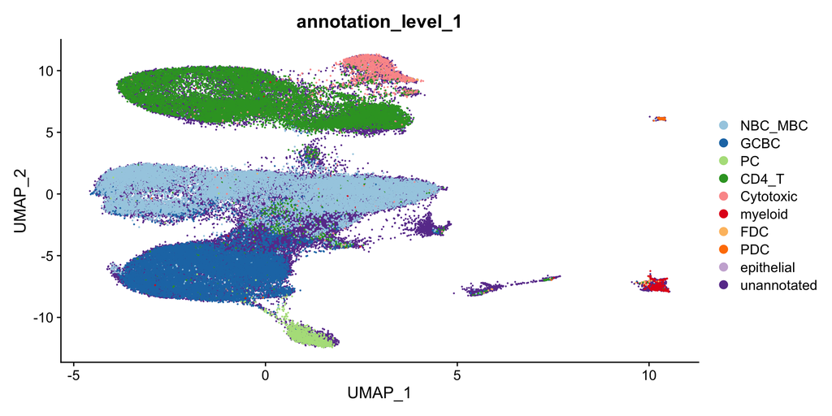

```r
p1 <- DimPlot(tonsil_ATAC,
  group.by = "annotation_level_1",
  cols = colors,
  pt.size = 0.1)

p1
```

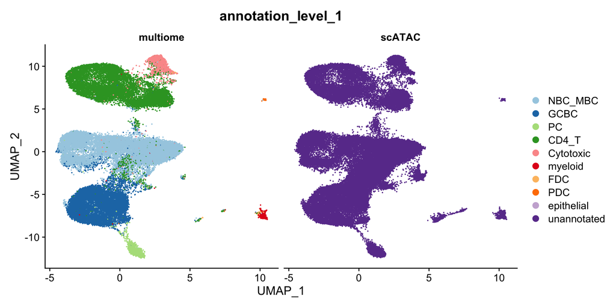

```r
p2 <- DimPlot(tonsil_ATAC,
  group.by = "annotation_level_1",
  pt.size = 0.1,
  cols = colors,
  split.by = "assay")


p2
```

# 3 KNN Algorithm

## 3.1 Data Splicing

Data splicing basically involves splitting the data set into training and testing data set.

```r
reference_cells <- colnames(tonsil_ATAC)[tonsil_ATAC$assay == "multiome"]
query_cells <- colnames(tonsil_ATAC)[tonsil_ATAC$assay == "scATAC"]

reduction_ref <- tonsil_ATAC@reductions[[reduction]]@cell.embeddings[reference_cells, dims]
reduction_query <- tonsil_ATAC@reductions[[reduction]]@cell.embeddings[query_cells, dims]
```

## 3.2 Cross-validation of the K parameter.

We’re going to calculate the number of observations in the training dataset that correspond to the Multiome data. The reason we’re doing this is that we want to initialize the value of ‘K’ in the KNN model. To do that, we split our training data in two part: a train.loan, that correspond to the random selection of the 70% of the training data and the test.loan, that is the remaining 30% of the data set. The first one is used to traint the system while the second is uses to evaluate the learned system.

```r
dat.d <- sample(1:nrow(reduction_ref),
               size=nrow(reduction_ref)*0.7,replace = FALSE)

train.loan  <- reduction_ref[dat.d,] # 70% training data
test.loan <- reduction_ref[-dat.d,] # remaining 30% test data

train.loan_labels <- tonsil_ATAC@meta.data[row.names(train.loan),]$annotation_level_1
test.loan_labels <- tonsil_ATAC@meta.data[row.names(test.loan),]$annotation_level_1

k.optm <- c()
k.values <- c()

for (i in c(2,4,6,8,16,32,64,128,256)){
 print(i)
 knn.mod <- knn(train=train.loan, test=test.loan, cl=train.loan_labels, k=i)
 k.optm <- c(k.optm, 100 * sum(test.loan_labels == knn.mod)/NROW(test.loan_labels))
 k.values <- c(k.values,i)
}
```

```
## [1] 2
## [1] 4
## [1] 6
## [1] 8
## [1] 16
## [1] 32
## [1] 64
## [1] 128
## [1] 256
```

Now we can plot the accuracy of the model taking in account a range of different K and selec the best one.

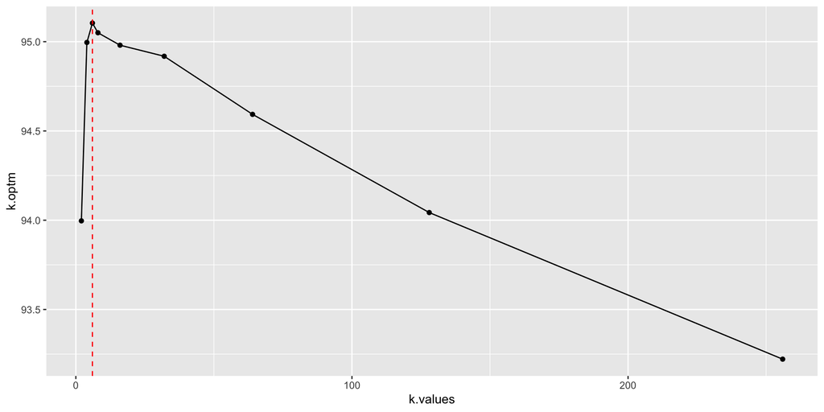

```r
k.optim = data.frame(k.values,k.optm)

p3 <- ggplot(data=k.optim, aes(x=k.values, y=k.optm, group=1)) +
 geom_line() +
 geom_point() +
 geom_vline(xintercept=6, linetype="dashed", color = "red")

p3
```

## 3.3 Building a Machine Learning model with the optimal k value.

```r
train.loan  <- reduction_ref
test.loan <- reduction_query

train.loan_labels <- tonsil_ATAC@meta.data[row.names(train.loan),]$annotation_level_1
test.loan_labels <- tonsil_ATAC@meta.data[row.names(test.loan),]$annotation_level_1

knn.mod <- knn(train=train.loan, test=test.loan, cl=train.loan_labels, k=6, prob=T)

annotation_data <- data.frame(query_cells, knn.mod, attr(knn.mod,"prob"))
colnames(annotation_data) <- c("query_cells",
                               "annotation_level_1",
                               "annotation_prob")

tonsil_ATAC@meta.data[annotation_data$query_cell,]$annotation_level_1 <- annotation_data$annotation_level_1
tonsil_ATAC@meta.data[annotation_data$query_cell,]$annotation_prob <- annotation_data$annotation_prob
tonsil_ATAC$annotation_level_1 <- factor(tonsil_ATAC$annotation_level_1)
```

## 3.4 Low-dimensionality representation of the assays

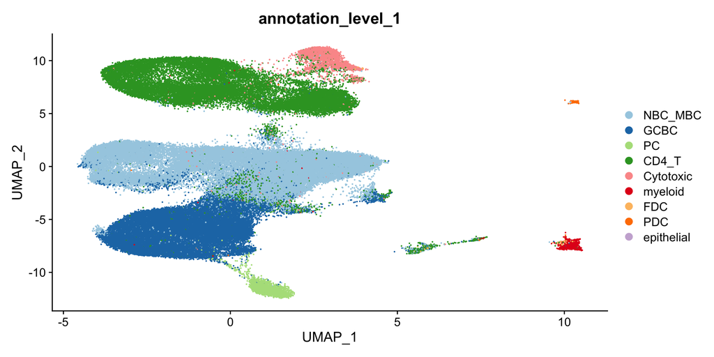

```r
p4 <- DimPlot(
  tonsil_ATAC,
  cols = colors,
  group.by = "annotation_level_1",
  pt.size = 0.1)


p4
```

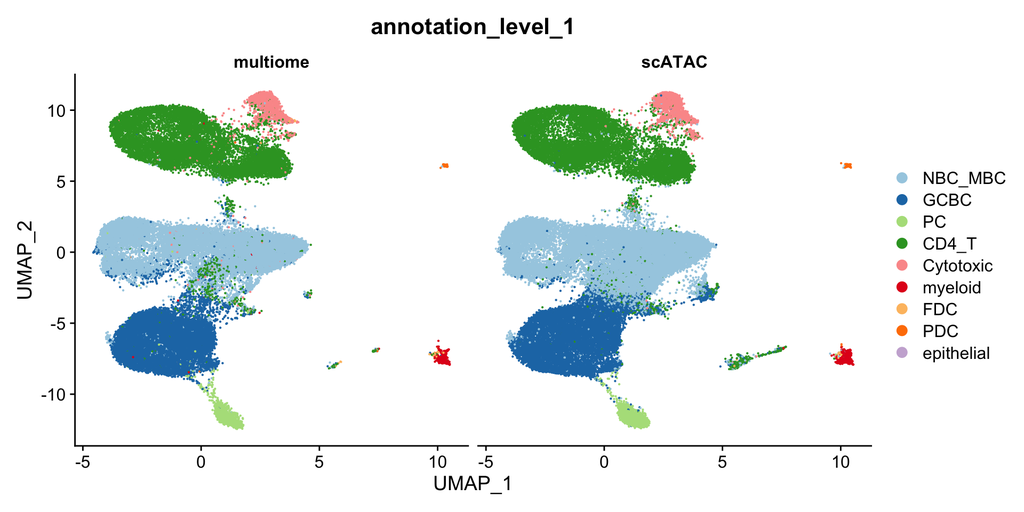

```r
p5 <- DimPlot(
  cols = colors,
  tonsil_ATAC, reduction = "umap",
  group.by = "annotation_level_1",
  pt.size = 0.1,  split.by = "assay")

p5
```

```r
melt(table(tonsil_ATAC$annotation_level_1))
```

```
##         Var1 value
## 1    NBC_MBC 41085
## 2       GCBC 27497
## 3         PC  2548
## 4      CD4_T 25011
## 5  Cytotoxic  3635
## 6    myeloid   876
## 7        FDC   113
## 8        PDC   310
## 9 epithelial     1
```

```r
saveRDS(tonsil_ATAC, path_to_save)
```

## 3.5 Low-dimensionality representation of the prediction probability

Note that the probability of the prediction was lower in the transitioning cells and in not-defined clusters.

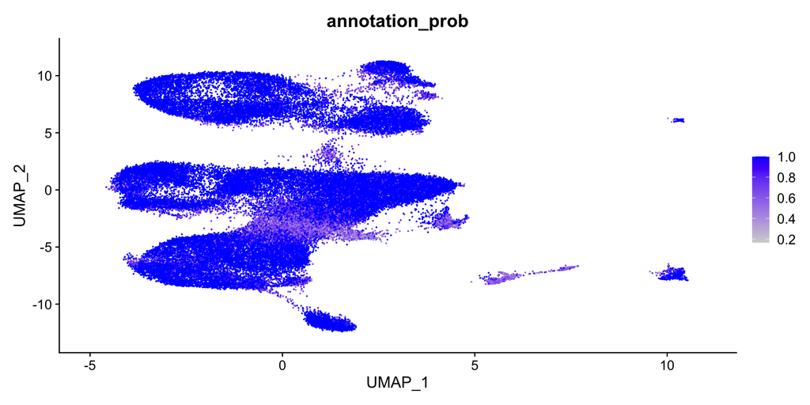

```r
tonsil_ATAC_scATAC = subset(tonsil_ATAC, assay == "scATAC")

p6 <- FeaturePlot(
  tonsil_ATAC_scATAC, reduction = "umap",
  features = "annotation_prob",
  pt.size = 0.1)

p6
```